# Reproducible Research: Peer Assessment 1

Paul K. Courtney

August 16, 2015

## Loading and preprocessing the data

```r
fit <- read.csv("activity.csv", header=TRUE)
summary(fit)
```

```
##      steps              date          interval
##  Min.   :  0    2012-10-01:  288   Min.   :   0
##  1st Qu.:  0    2012-10-02:  288   1st Qu.: 589
##  Median :  0    2012-10-03:  288   Median :1178
##  Mean   : 37    2012-10-04:  288   Mean   :1178
##  3rd Qu.: 12    2012-10-05:  288   3rd Qu.:1766
##  Max.   :806    2012-10-06:  288   Max.   :2355
##  NA's   :2304   (Other)   :15840
```

```r
library(plyr)
library(dplyr)
```

```r
library(ggplot2)
```

I did not see the need for pre-processing at this point in time.

## What is mean total number of steps taken per day?

```r
by_date_fit <- group_by(fit, date)
tot_steps <- summarise(by_date_fit, steps=sum(steps))
summary(tot_steps)
```

```
##          date        steps
##  2012-10-01: 1   Min.   :   41
##  2012-10-02: 1   1st Qu.: 8841
##  2012-10-03: 1   Median :10765
##  2012-10-04: 1   Mean   :10766
##  2012-10-05: 1   3rd Qu.:13294
##  2012-10-06: 1   Max.   :21194
##  (Other)   :55   NA's   :8
```

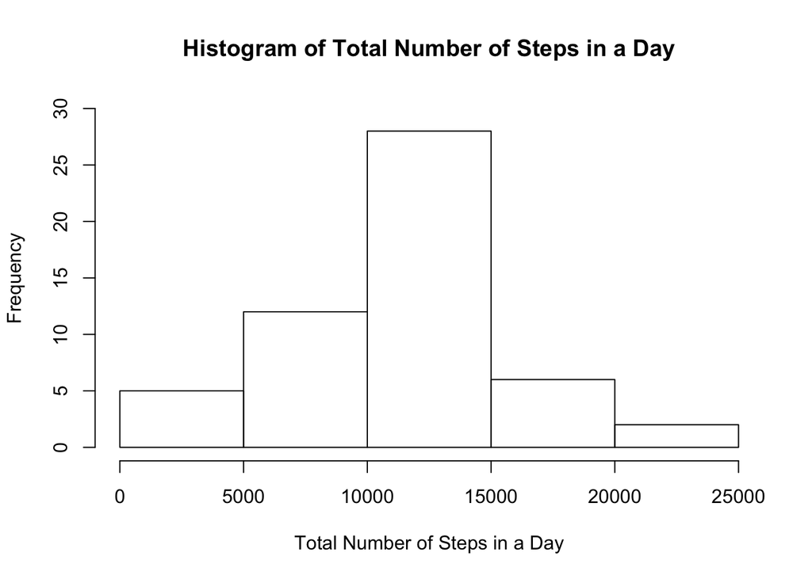

```r
hist(tot_steps$steps, freq=TRUE, main="Histogram of Total Number of Steps in a Day", xlab="Total Number of Steps in a Day", ylab="Frequency", ylim=c(0,30))
```

```r
mean_steps <- mean(tot_steps$steps, na.rm=TRUE)
median_steps <- median(tot_steps$steps, na.rm=TRUE)
```

The mean value of the total number of the steps taken each day is 10766.19 and the median value is 10765.

## What is the average daily activity pattern?

So here we will need to rearrange the dataset “fit” in order to view the data as an average of the number of steps for each 5-minute interval of the day. The dataset we want will have columns “interval” and “steps”.

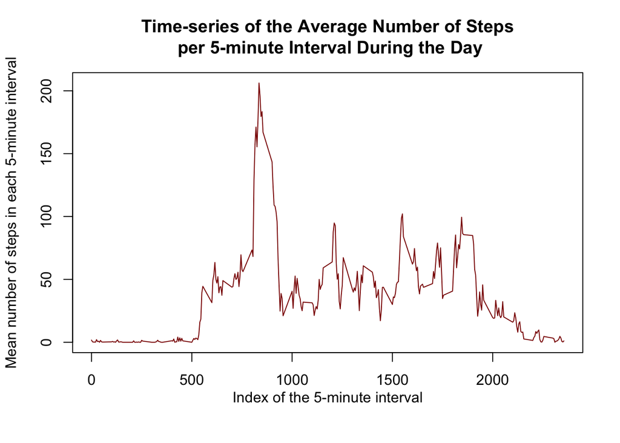

```r
by_interval_fit <- group_by(fit, interval)
mean_interval <- summarise(by_interval_fit, steps=mean(steps, na.rm=TRUE))
max_interval <- mean_interval[ mean_interval$steps == max(mean_interval$steps, na.rm=TRUE), ]$interval
plot(mean_interval$interval, mean_interval$steps, type="l", xlab="Index of the 5-minute interval\n", ylab="Mean number of steps in each 5-minute interval", main="Time-series of the Average Number of Steps\n per 5-minute Interval During the Day", col="dark red")
```

The 5 minute interval that has the maximum average number of steps is 835.

## Imputing missing values

The presence of missing days may introduce bias into some calculations or summaries of the data. So let’s calculate and report the total number of missing values in the dataset (i.e. the total number of rows with ‘NA’s). When we loaded and pre-processed the data we saw that the only column with NA’s is ’steps’. In any case, we can use the function “complete.cases” to return a boolean vector where “TRUE”" indicates that the variable step is not ‘NA’ and “FALSE” indicates that step is ‘NA’.

```r
fit_complete <- complete.cases(fit)
## Since TRUE values will be converted to "1" and FALSE values to "0" we can use the function "sum" to infer the number
## of complete cases. We can simply subtract the number of complete cases from the total number of cases (length of the
## vector) to arrive at the number of incomplete cases.
fit_NA <- length(fit_complete) - sum(fit_complete)
```

The total number of incomplete cases (i.e. those with NA in one or more columns) is 2304.

So we can impute values for NA, meaning replace the missing value with one that is somehow representative of what the data might be at that interval. I will select the mean for that particular interval across all dates. We already have that value calculated from the section about the Daily Activity Pattern. So we can just replace the ‘NA’ value with the mean value from the data frame ‘mean_interval’ for that interval.

```r
## First merge the datasets fit and mean_interval on the variable interval
fit_merged <- merge(fit, mean_interval, by = "interval")
## Now select the value of steps into a new column, 'new_steps' based on whether steps.x is 'NA' or not
fit_imputed <- mutate(fit_merged, new_steps = round(ifelse(is.na(steps.x),steps.y,steps.x)))

## We can now set the variables steps.x and steps.y to NULL and rename "new_steps" to just "steps"
fit_imputed$steps.x <- NULL
fit_imputed$steps.y <- NULL
names(fit_imputed) <- c("interval", "date", "steps")
```

Now we have a new dataset, fit_NA_imputed, from which we can produce a histogram of steps and some summary statistics.

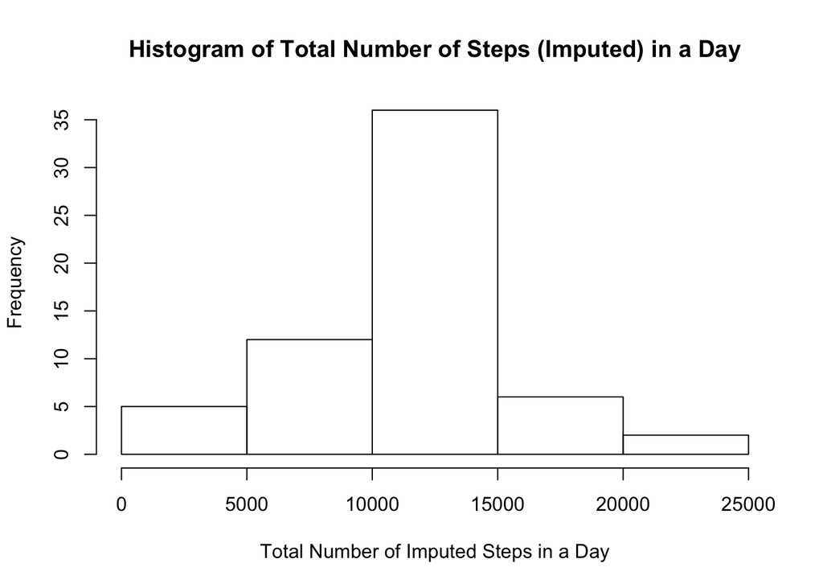

```r
by_date_fit_imputed <- group_by(fit_imputed, date)
tot_steps_imputed <- summarise(by_date_fit_imputed, steps=sum(steps))

hist(tot_steps_imputed$steps, freq=TRUE, main="Histogram of Total Number of Steps (Imputed) in a Day", xlab="Total Number of Imputed Steps in a Day", ylab="Frequency")
```

```r
mean_steps_imputed <- mean(tot_steps_imputed$steps)
median_steps_imputed <- median(tot_steps_imputed$steps)
```

First lets compare this histogram with the original. The shape is very similar, so we could say that the imputation of values has not materially affected the overall shape of the data in a histogram.

Second, let’s look at the mean and the median. Our new imputed mean is 10765.64, which is just 0.55 less than the non-imputed mean. And our new imputed median is 10762, only 3 less than the non-imputed median.

It would appear that imputing values based on the overall mean at the interval level of selection produces very good agreement with the non-imputed values.

## Are there differences in activity patterns between weekdays and weekends?

So here we will use the dataset with imputed values, fit_imputed. We will add a variable of type Factor with values of “weekday” or “weekend” depending on whether the date falls on Monday through Friday or on Saturday to Sunday. We will then create a time series plot across the intervals to compare the activity over the day on a weekday and a weekend.

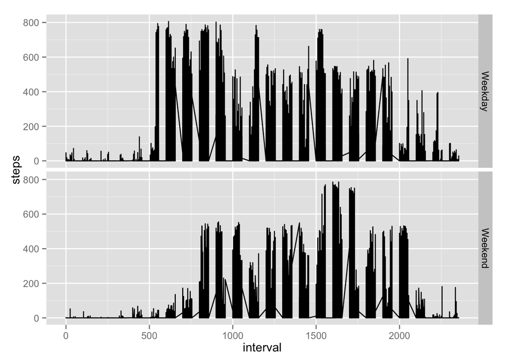

```r
##Let's first convert the date from a factor to a date
fit_imputed$date <- as.Date(fit_imputed$date)
fit_imputed <- mutate(fit_imputed, weekday = ifelse( weekdays(date) %in% c("Sunday", "Saturday"), "Weekend", "Weekday") )
fit_imputed <- mutate(fit_imputed, weekday = as.factor(weekday)) #converts weekday to factor

p <- ggplot(fit_imputed, aes(interval, steps), ylab="Number of Steps", xlab="Interval") + geom_line()
p + facet_grid(weekday ~ .)
```

Although this plot doesn’t look exactly the same as the one provide, I believe this does still give us the ability to make some overall observations. one is that there is much more activity on the weekdays starting just after 5:00 am (interval 500), whereas on the weekend it looks like activity is more likely to increase at around 8:00 am. Secondly, the activity on a weekday seems to be somewhat shifted to the earlier hours and is reduced in the evenings, whereas on the weekends, the activity is shifted to the later hours of the afternoon and evening.